# Longitudinal Climate Change Analysis

Vladyslav Shuvalov

November 13, 2019

## Introduction

The Mauna Lao Observatory in Hawaii has been observing atmospheric carbon dioxide concentrations since the year 1960 to present day. This report will observe whether major world events have impacted the carbon dioxide concentrations in the world’s atmosphere. The world events being: the OPEC oil embargo which began in October 1973, the global economic recessions around 1980-1982, the fall of the Berlin wall almost exactly 30 years ago, preceding a dramatic fall in industrial production in the Soviet Union and Eastern Europe, China joining the WTO on 11 December 2001, which was followed by rapid growth in industrial production, the bankruptcy of Lehman Brothers on 15 September 2008, regarded as the symbolic start of the most recent global financial crisis, and the signing of the Paris Agreement on 12 December 2015, intended to limit CO2 emissions.

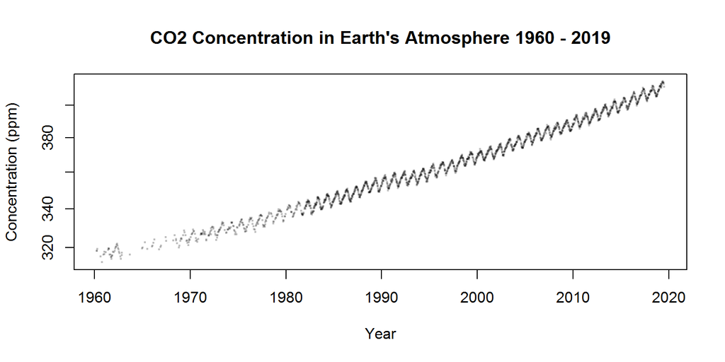

The Mauna Lao Observatory in Hawaii has been observing atmospheric carbon dioxide concentrations since the year 1960. Many of the early observations taken were low quality measurements. Low quality measurements have been removed in this report. Even with the removal of low quality measurements there is a clear upward trend in carbon dioxide concentrations.

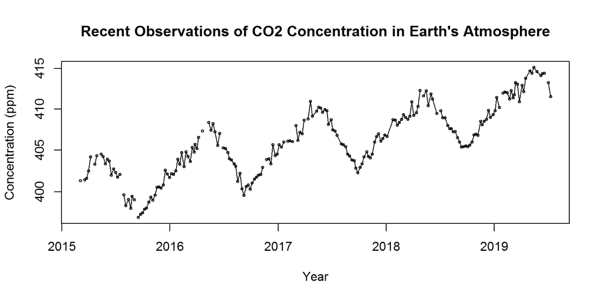

## Methods

To model the observed data periodic annual and biannual effects have been used to account for seasonal effects on carbon dioxide concentrations. A gamma linear model was used to observe the trend of carbon dioxide concentrations $log(CO2) = \beta_1sin(2\pi*year) + \beta_2cos(2\pi*year) + \beta_3sin(4\pi*year) + \beta_4cos(4\pi*year) + U(day) + V_i$ where $\beta_1$ and $\beta_2$ are annual temperature effects, $\beta_3$ and $\beta_4$ are biannual temperature effects, $U(day)$ represents a second-order random walk. The prior chosen for the stardard deviation of the random walk is $P(\sigma<\frac{log(1.01)}{26})=0.5$ with a prior on the variance of $P(\sigma<2)=0.5$

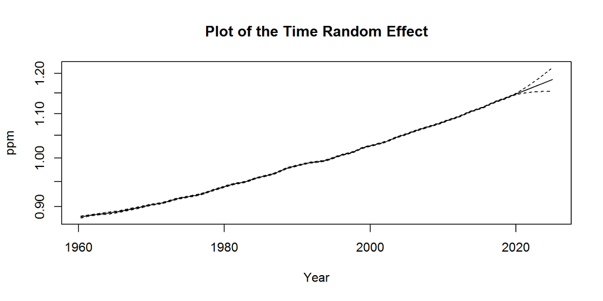

Plot of Random Effect

The rate of change of carbon dioxide concentrations is modelled by predicting the derivative of the fitted model. The figures below show prediction of the monthly and overall rate of change of carbon dioxide concentrations. Major world events are highlighted at 5 year intervals after their occurance. The red interval highlights the OPEC oil embargo which began in October 1973, blue interval highlights the global economic recessions around 1980-1982, yellow interval highlights the fall of the Berlin wall, pink interval highlights China joining the WTO, Orange interval highlights the bankruptcy of Lehman Brothers, the symbolic start of the most recent global financial crisis, and the green line marks the signing of the Paris Agreement intended to limit CO2 emissions.

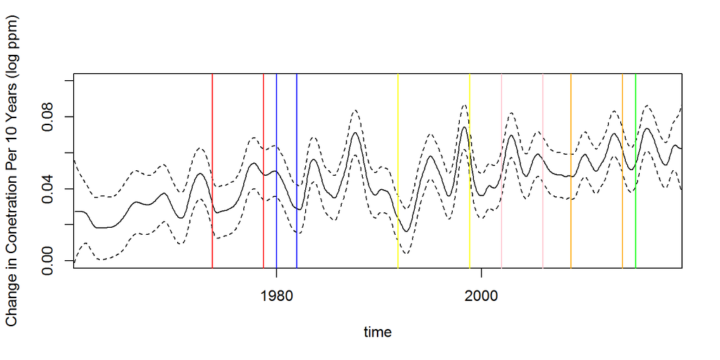

The figures below show seasonal and future predicted carbon dioxide concentrations given by the fitted model.

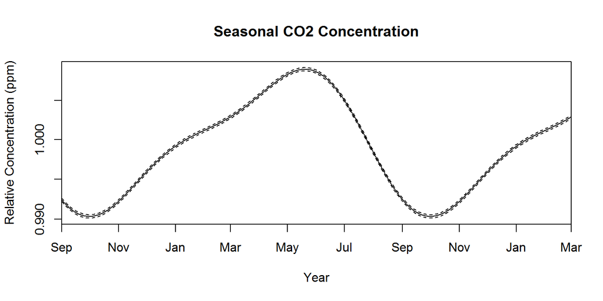

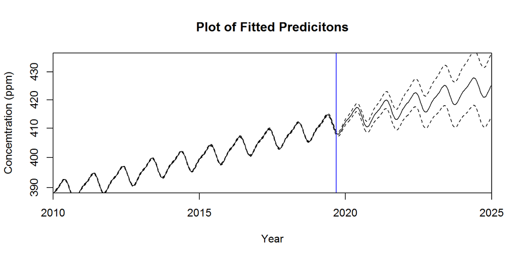

## Introduction

The IPCC states that Human activities are estimated to have caused approximately 1.0°C of global warming above preindustrial levels, with a likely range of 0.8°C to 1.2°C. Global warming is likely to reach 1.5°C between 2030 and 2052 if it continues to increase at the current rate. (high confidence)

There have been recent arguements made against the existance of climate change and its impacts. This report will examine data recorded on Sable Island, off the coast of Nova Scotia to determine whether there is evidence to show a change in global temperature.

Examining the scatterplot of the complete record of Sable Island temperature records shown below initially shows no relationship.

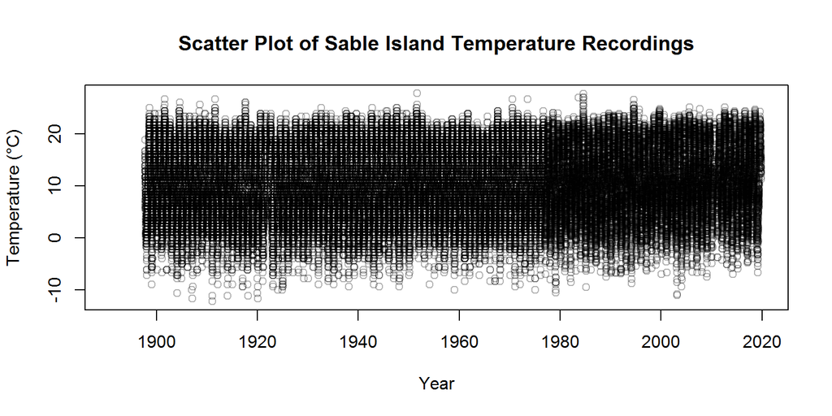

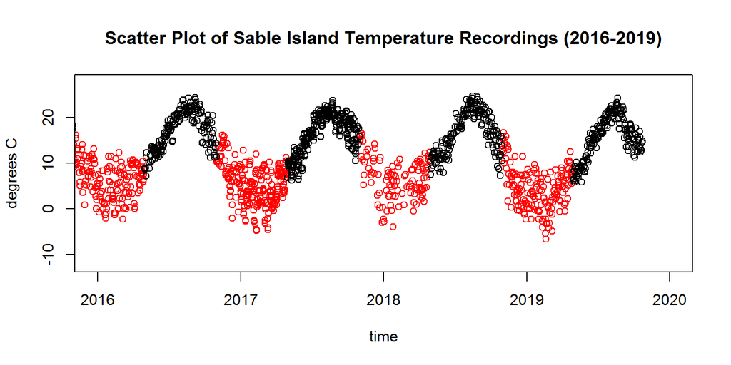

Summer months are shown in black

## Method

To model the Sable Island temperature data the model $Temperature = \beta_0 + \beta_1sin(\frac{2\pi day}{365.25}) + \beta_2cos(\frac{2\pi day}{365.25}) + \beta_3sin(\frac{4\pi day}{365.25}) + \beta_4cos(\frac{4\pi day}{365.25}) + U(week) + V(week) + W(year)$ was chosen where $\beta_1$ and $\beta_2$ are annual temperature effects, $\beta_3$ and $\beta_4$ are biannual temperature effects, $U(week)$ is a second-order random walk for week, V(week) is the random effect for week, and W(year) is the random effect for year.

The prior chosen for the standard deviation of the second-order random walk is $P(\sigma<\frac{0.1}{52*100})=0.05$, the prior for the standard deviation of the random intercept for week is $P(\sigma<1)=0.5$, the prior chosen for the standard deviation of the random intercept for year is $P(\sigma<1)=0.5$.

|  | 0.5quant | 0.025quant | 0.975quant |
| --- | --- | --- | --- |
| sin12 | -4.676 | -5.192 | -4.161 |
| cos12 | 4.763 | 4.473 | 5.052 |
| sin6 | -2.049 | -2.272 | -1.826 |
| cos6 | -0.152 | -0.324 | 0.019 |

|  | mean | 0.025quant | 0.975quant |
| --- | --- | --- | --- |
| sd for t | 1.770 | 1.749 | 1.793 |
| sd for week | 0.000 | 0.000 | 0.000 |
| sd for weekIid | 1.092 | 1.057 | 1.132 |
| sd for yearFac | 0.706 | 0.610 | 0.833 |

The figure below shows a plot of 24 posterior samples. The samples show an upwards trend in temperature. The dotted lines represent the 95% confidence interval of the mean of the trend. With future predictions of 1.5 degree increase since the year 1900.

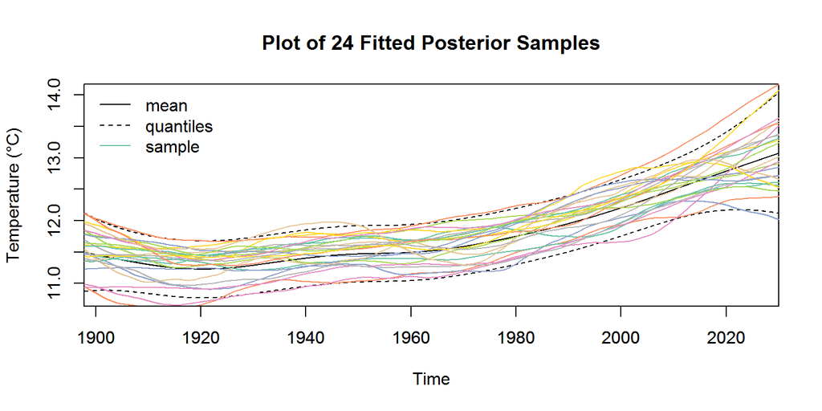

Plot of 24 posterior samples

## Conclusion

In conclusion data supports evidence to show that there is an increase in global temperatures coinciding with IPCC reports of 1.0 degree of global warming above preindustrial levels, with a likely range of 0.8 degrees to 1.2 degrees. Future predictions of 1.5 degree increase in temperature coincide with the predictions made using the Sable Island data.